# ENVS 4826 A2 - Scientific Paper Summary

GitHub: [link](https://github.com/jenacyrae/ENVS4826-A2)

Jenacy Samways

25/09/2020

### Introduction

Just when it seemed 2020 couldn’t get worse, we were hit with the news in late May that giant “murder hornets” were invading North America and would soon be terrorizing our backyards. Although these Asian giant hornets, which are the largest species on Earth, do not pose as much of a dangerous threat to humans as popular media would lead you to believe, there are still severe implications to their invasion of North America. The most significant threat of the Asian giant hornet, scientific name *V. mandarinia*, is that it is a known predator of honeybees, which provide important ecosystem services such as pollination. Therefore, it is very important that we are able to determine, estimate and control the spread of *V. mandarinia*. A recent scientific paper by Zhu et al. aims to do just that, using scientific modelling to determine their possible niches and measure the potential extent of their dispersion into North America.

### Methods

In order to develop global models of the expected distribution of *V. mandarinia*, many factors needed to be assessed. First, the authors obtained information on the environmental factors affecting *V. mandarinia*, covering constraints such as climate, competition, and predation. Next, they looked at the realized niches of both native and introduced populations of *V. mandarinia*. To predict the ecological niche, models were used to assess habitat suitability in North America. They also mapped human footprint with climate suitability as human-modified habitats are often more susceptible to invasion. With this information, they created a dispersal simulation which estimated the spread of *V. mandarinia* over the next twenty years under two possible dispersal scenarios - one which account for short-distance dispersal only and one which accounted for both short- and long-distance dispersal.

### Results and Conclusion

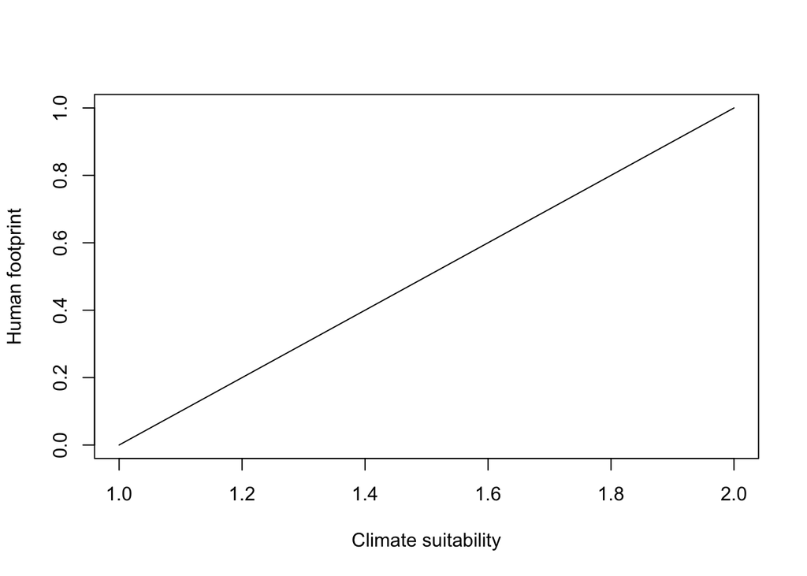

**Figure 1:** The proposed relationship between human footprint and climate suitability

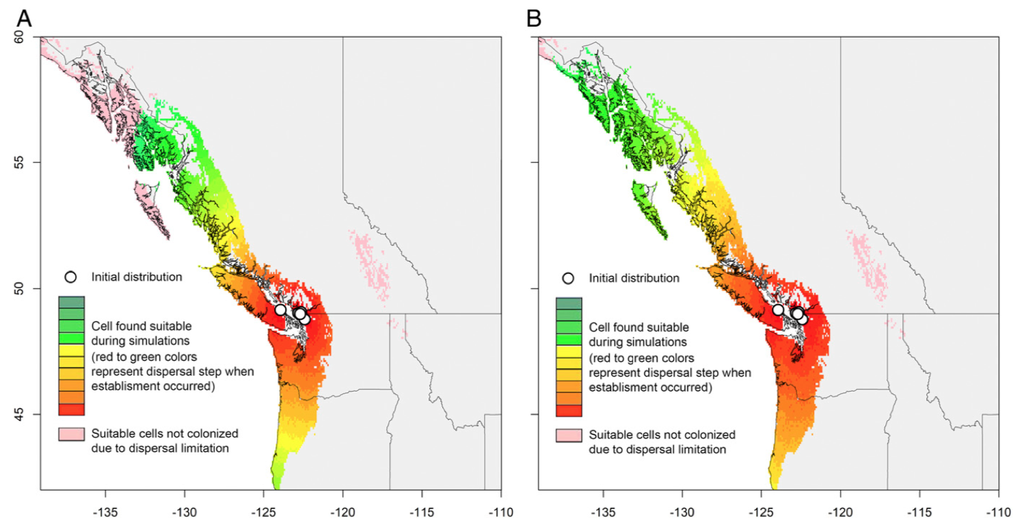

**Figure 2:** A model of the estimated dispersion of *V. mandarinia* over the next 20 years under two different scenarios: Scenario A, which accounts for short distance disperal only; and Scenario B - which accounts for both short and long distance dispersal.

In conclusion, it is clear to see that the invasion of the Asian giant hornet is an important issue for which action needs to be taken to prevent its future spread. This species’ recent introduction to North America needs to be closely monitored, and every effort should be made to eradicate *V. mandarinia* before it can spread futher. Finally, areas which are vulnerable to invasion due to their high climate suitability and high human footprint need to be carefully watched and protected as well.

### Bibliography

Zhu, G., Illan, J. G, Looney, C., & Crowder, D. W. Assessing the ecological niche and invasion potential of the Asian giant hornet. Proceedings of the National Academy of Sciences, 2020; 202011441 DOI: 10.1073/pnas.2011441117